# Preprocessing and Early Models

#### A study of Asian Religious and Biblical Texts Data Set

Adrianna Grudzień, Mateusz Stączek

Data: [archive.ics.uci.edu](https://archive.ics.uci.edu/ml/datasets/A+study+of++Asian+Religious+and+Biblical+Texts)

Related article: [www.researchgate.net](https://www.researchgate.net/publication/338137955_What_do_Asian_Religions_Have_in_Common_An_Unsupervised_Text_Analytics_Exploration)

### Introduction

In this task, there are 8 religious texts, 4 from Asia, 4 Biblical:

- Upanishads,
- Yoga Sutras,
- Buddha Sutras,
- Tao Te Ching,
- Book of Wisdom,
- Book of Proverbs,
- Book of Ecclesiastes,
- Book of Ecclesiasticus.

Each text has been divided into chapters (590 chapters in total) and the goal is to divide these chapters into clusters matching book of origin. This notebook contains various preprocessing steps as well as a few basic models.

### Reading provided data

```python
import warnings
warnings.filterwarnings('ignore')
import pandas as pd
import numpy as np
import re
import nltk
from nltk import PorterStemmer, WordNetLemmatizer, word_tokenize
from nltk.tokenize import sent_tokenize
nltk.download('punkt', quiet=True)
nltk.download('wordnet', quiet=True)
nltk.download('stopwords', quiet=True)
from nltk.corpus import stopwords
import seaborn as sns
sns.set_theme(style="whitegrid")
import matplotlib.pyplot as plt
from wordcloud import WordCloud
from sklearn.feature_extraction.text import CountVectorizer
import gensim
import pyLDAvis
import pyLDAvis.gensim_models
from tqdm import tqdm
```

```python
df_csv = pd.read_csv('AllBooks_baseline_DTM_Unlabelled.csv')
```

### Reading raw texts and preprocessing

We repeat cleaning process from the EDA.

TODO: removing unnecessary punctuation marks, special characters and ancient English words which were not recognized as stop words by NLTK library?

```python
# reading row txt
with open('Complete_data.txt', 'r',encoding='latin-1') as file:
    txt = file.read()

chapters = re.split('\n\d\.\d+\n', txt)
chapters = [re.sub(r'\d\.\d+\n','',text) for text in chapters]
to_pop=[]
for i in range(len(chapters)):
    if chapters[i].strip()=='':
        to_pop.append(i)
for index in to_pop:
    chapters.pop(index)
```

```python
# cleaning Bible verses
chapters = [re.sub(r'\s\d+:\d+\.','',text) for text in chapters]
# cleaning Bible chapters info
chapters = [re.sub(r'\s\s[A-Z][a-z]+\sChapter\s\d+\s','',text) for text in chapters]
# cleaning Buddha Sutras chapter numbers
chapters = [re.sub(r'§ \d+\.','',text) for text in chapters]

# to lowercase !!!
chapters = [text.lower() for text in chapters]

# # removing empty chapters - earlier we have found that chapter 14 is empty
chapter_lengths = [len(x) for x in chapters]
empty_chapters = [i for i in range(len(chapter_lengths)) if chapter_lengths[i] == 0 ]
chapters = [chapters[i] for i in range(len(chapters)) if i not in empty_chapters]
```

```python
# removing stop words (warning: takes around 7min30s)
chapters_without_stopwords = [0] * len(chapters)
for i in tqdm(range(len(chapters))):
    text_tokens = word_tokenize(chapters[i]) # removing punctuation
    tokens_without_sw = [word for word in text_tokens if word not in stopwords.words()]
    chapters_without_stopwords[i] = " ".join(tokens_without_sw)
```

## Preprocessing

Next, we prepare a data frame `df_chapters` containing all useful information from the EDA, that is:

- chapter length,
- number of sentences,
- average sentence length,
- number of words (without stopwords),
- number of unique words (without stopwords),
- average word length,
- chapter complexity (flesch reading ease),
- positive/negative/neutral tinting of chapter,
- bag of words instead of texts.

```python
df_chapters = pd.DataFrame(chapters, columns=['raw_chapter'])

df_chapters["chapter_length"] = [len(x) for x in chapters]
df_chapters["num_of_sentences"] = [len(sent_tokenize(x)) for x in chapters]
df_chapters["avg_sentence_len"] = [np.average([len(y) for y in sent_tokenize(x)]) for x in chapters]

# removing punctuation
tokenizer = nltk.RegexpTokenizer(r"\w+")
for i in range(len(chapters_without_stopwords)):
    text_tokens = tokenizer.tokenize(chapters_without_stopwords[i])
    chapters_without_stopwords[i] = " ".join(text_tokens)

df_chapters['num_of_words'] = [len(x.split()) for x in chapters]
df_chapters['num_of_words_wo_stopwords'] = [len(x.split()) for x in chapters_without_stopwords]
df_chapters['num_of_uniq_words'] = [len(set(x.split())) for x in chapters]
df_chapters['num_of_uniq_words_wo_stopwords'] = [len(set(x.split())) for x in chapters_without_stopwords]

import re
def num_of_letters(text):
    return len(re.findall('[a-zA-Z]',text))
df_chapters['num_of_letters'] = [num_of_letters(x) for x in chapters]

df_chapters['avg_word_length'] = df_chapters['num_of_letters'] / df_chapters['num_of_words']

from textstat import flesch_reading_ease
df_chapters["text_complex_fre"] = df_chapters.raw_chapter.apply(lambda x : flesch_reading_ease(x))

from textblob import TextBlob
df_chapters['polarity'] = [TextBlob(x).sentiment.polarity for x in chapters]
df_chapters['subjectivity'] = [TextBlob(x).sentiment.subjectivity for x in chapters]
```

### Adding bag of words and removing raw texts

```python
df_chapters.drop('raw_chapter', axis=1, inplace=True)

cv = CountVectorizer(stop_words='english',token_pattern=r"\b[a-z]+\b",min_df=2)
df_bow = pd.DataFrame(cv.fit_transform(chapters).toarray(), columns=cv.get_feature_names())
```

```python
df_chapters_with_bow = pd.concat([df_chapters,df_bow], axis=1)
df_chapters_with_bow.iloc[:2, :15]
```

|  | chapter_length | num_of_sentences | avg_sentence_len | num_of_words | num_of_words_wo_stopwords | num_of_uniq_words | num_of_uniq_words_wo_stopwords | num_of_letters | avg_word_length | text_complex_fre | polarity | subjectivity | aaron | abandoned | abandoning |
| --- | --- | --- | --- | --- | --- | --- | --- | --- | --- | --- | --- | --- | --- | --- | --- |
| 0 | 3628 | 28 | 129.035714 | 602 | 299 | 168 | 85 | 2839 | 4.715947 | -524.34 | -0.059836 | 0.395902 | 0 | 0 | 0 |
| 1 | 1509 | 15 | 99.933333 | 265 | 107 | 101 | 48 | 1171 | 4.418868 | -172.13 | 0.117647 | 0.477941 | 0 | 0 | 0 |

### Normalization

Due to presence of outliers, we use Robust Scaler instead of a more default one - Standard Scaler.

```python
from sklearn.preprocessing import RobustScaler
scaler = RobustScaler()

df_scaled_chapters_no_bow = pd.DataFrame(scaler.fit_transform(df_chapters),
                                index=df_chapters.index,
                                columns=df_chapters.columns)
df_scaled_chapters = pd.DataFrame(scaler.fit_transform(df_chapters_with_bow),
                                index=df_chapters_with_bow.index,
                                columns=df_chapters_with_bow.columns)
df_scaled_csv =  pd.DataFrame(scaler.fit_transform(df_csv),
                                index=df_csv.index,
                                columns=df_csv.columns)
```

### Saving processed dataframe to csv

```python
df_scaled_chapters.to_csv("Processed_our_dataframe.csv", index=False)
```

```python
# to read:
# pd.read_csv("Processed_our_dataframe.csv")
```

## K-Means elbow method with and without PCA

`whiten=True` is set, explanation [here](http://ufldl.stanford.edu/tutorial/unsupervised/PCAWhitening).

In this section there are 3 parts. Each is about KMeans trained on a different dataframe, PCA and the best number of clusters. Dataframes are used in the following order:

- only statistical information about texts
- both statistical information and a small bag of words
- no statistical information and a big bag of words (the one provided)

Before we begin, here are a few useful functions. PCA is set to preserve at least 93% percent of variance.

```python
from sklearn.decomposition import PCA
from sklearn.cluster import KMeans
import numpy as np

def pca_plot(df, title=''):
    pca = PCA(whiten=True).fit(df)
    plt.figure(figsize=(9,6))
    plt.plot(range(1, len(pca.explained_variance_ratio_)+1), np.cumsum(pca.explained_variance_ratio_))
    plt.xlabel('number of components')
    plt.ylabel('cumulative explained variance')
    plt.title(title);

def make_plot(scores, x=None, title=''):
    x = x or list(range(1,len(scores) + 1))
    plt.figure(figsize=(6,4))
    plt.plot(x, scores)
    plt.xlabel('number of clusters')
    plt.ylabel('score (lower means clusters are tighter)')
    plt.ylim(0, plt.ylim()[1]*1.05)
    plt.title(title);

def elbow_method(df,title="Elbow method scores", k_max=None):
    k_max = k_max or 10
    scores = []
    for k in range(1, k_max+1):
        kmeans = KMeans(random_state=0, n_clusters=k).fit(df)
        scores.append(kmeans.score(df) * -1)
    make_plot(scores, x=list(range(1,k_max + 1)), title=title)

def elbow_method_PCA_93percent(df,title="Elbow method scores with PCA", k_max=None):
    elbow_method(PCA(whiten=True, n_components=0.93).fit_transform(df),title=title, k_max=k_max)
```

#### Dataset 1 - only statistical information

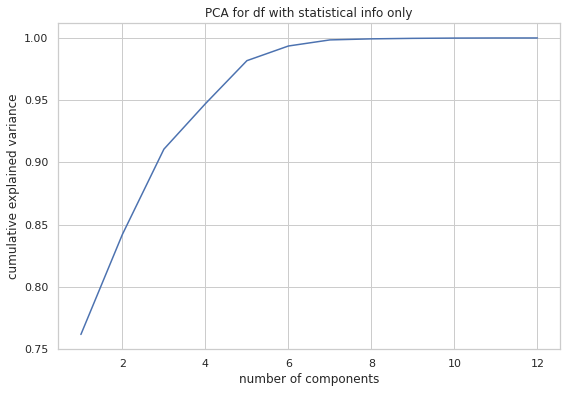

```python
pca_plot(df_scaled_chapters_no_bow, 'PCA for df with statistical info only')
```

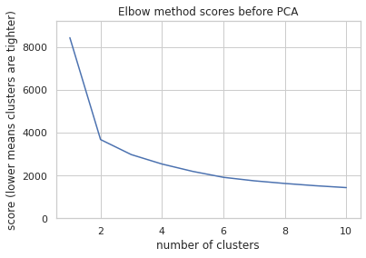

```python
elbow_method(df_scaled_chapters_no_bow, title="Elbow method scores before PCA")
```

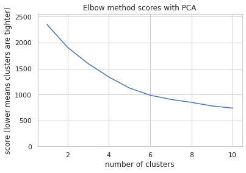

```python
elbow_method_PCA_93percent(df_scaled_chapters_no_bow)
```

#### Dataset 2 - statistical information and small BoW

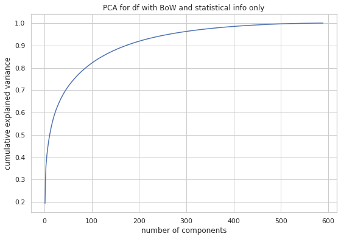

```python
pca_plot(df_scaled_chapters, 'PCA for df with BoW and statistical info only')
```

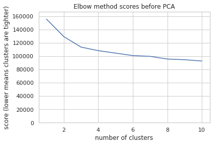

```python
elbow_method(df_scaled_chapters, title="Elbow method scores before PCA")
```

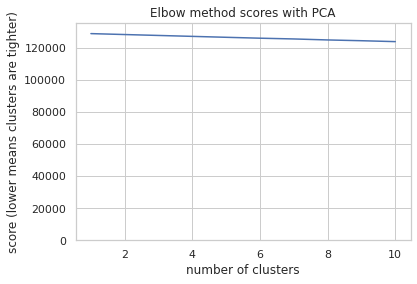

```python
elbow_method_PCA_93percent(df_scaled_chapters)
```

#### Dataset 3 - big BoW without statistical info

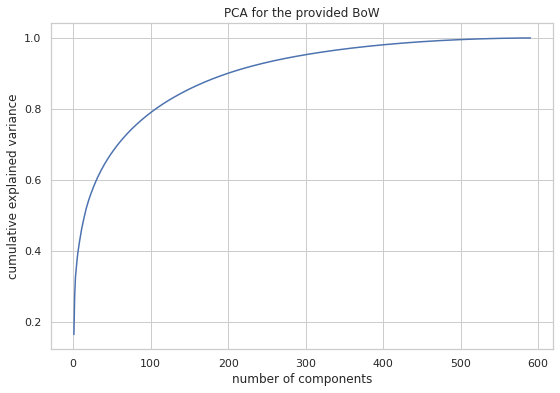

```python
pca_plot(df_scaled_csv, 'PCA for the provided BoW')
```

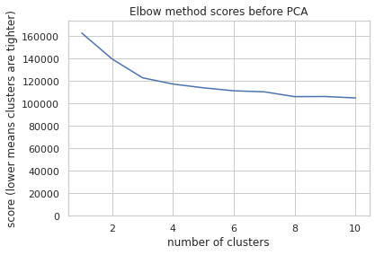

```python
elbow_method(df_scaled_csv, title="Elbow method scores before PCA")
```

[figure not shown]

```python
elbow_method_PCA_93percent(df_scaled_chapters)
```

### K-Means with and without PCA - Summary

PCA flattens Elbow Method score plots.

Best number of clusters is 2 or 3 (selected after countless hours spent staring at the plots above ;p).

## K-Means visualizations

In this part we won't use all 3 datasets tested previously - instead, we focus only on the data prepared by us (the dataset which includes statistical info only). Plots below were created for 2 PCA components. But first, we need to know the real answers.

```python
# to read our preprocessed dataframe:
# df_scaled_chapters = pd.read_csv("Processed_our_dataframe.csv")
# df_scaled_chapters_no_bow = df_scaled_chapters.iloc[:,:12]
```

#### Reading real labels

We want to use real labels to compare our results with the original data.

```python
labels = pd.read_csv('AllBooks_baseline_DTM_Labelled.csv').iloc[:,0]
del labels[13] # this chapter is empty and has been deleted at the beginning
labels = [x.split('_')[0] for x in labels]
df_labels = pd.DataFrame(labels, columns=['8labels'])
```

As presented in the article, we also divide all chapters into 4 main religions to which they belong. (useful for plots later)

```python
df_labels['4labels'] = df_labels['8labels'].replace({
        'Buddhism' : 'Buddhism',
        'TaoTeChing' : 'Taoism',
        'Upanishad' : 'Hinduism',
        'YogaSutra' : 'Hinduism',
        'BookOfProverb' : 'Christianity',
        'BookOfEcclesiastes' : 'Christianity',
        'BookOfEccleasiasticus' : 'Christianity',
        'BookOfWisdom' : 'Christianity'
    })
```

Some sources suggest the sufficient number of components for PCA as such that 90-95% of variance is preserved. ([source](https://www.mikulskibartosz.name/pca-how-to-choose-the-number-of-components/))

To find the minimal number of components preserving `0.9` of overall data variance, we can easily use the `n_components` parameter in PCA from sklearn package and set it to `0.9`. The result is presented below (here again, the dataset used contains statistical info about chapters only, no BoW).

```python
pca_90 = PCA(n_components = 0.90)
pca_90.fit(df_scaled_chapters_no_bow)
n_components = len(pca_90.explained_variance_ratio_)
print('Minimal number of components to preserve 90% of variance is', n_components)
```

```
Minimal number of components to preserve 90% of variance is 3
```

### PCA with 2 components (for visualizations)

```python
# compression for 2 components
pca_n_2 = PCA(n_components=2)
X_compressed = pca_n_2.fit_transform(df_scaled_chapters_no_bow)
X_compressed = pd.DataFrame(X_compressed)
X_compressed.shape
```

```
(589, 2)
```

```python
X_compressed.head(3)
```

|  | 0 | 1 |
| --- | --- | --- |
| 0 | 5.081473 | 1.575978 |
| 1 | 0.484307 | -0.062652 |
| 2 | 2.542037 | -0.425069 |

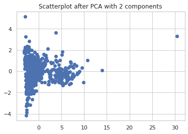

```python
plt.scatter(X_compressed.iloc[:,0], X_compressed.iloc[:,1])
plt.title("Scatterplot after PCA with 2 components")
plt.show()
```

### KMeans

```python
from sklearn.cluster import KMeans

# funkcja z materiałów z zajęć
def plot_kmeans_clusters(X, n_clusters):
    kmeans = KMeans(n_clusters=n_clusters, random_state=0)
    kmeans.fit(X)
    y_kmeans = kmeans.predict(X)
    plt.figure(figsize = (6, 4))

    plt.scatter(X.iloc[:, 0], X.iloc[:, 1], c=y_kmeans, s=30, cmap='viridis')

    centers = kmeans.cluster_centers_
    plt.scatter(centers[:, 0], centers[:, 1], c='black', s=200, alpha=0.75)
    plt.title('K-means clusters n_clusters = ' + str(n_clusters))
    plt.show()
```

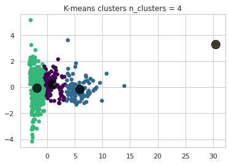

```python
plot_kmeans_clusters(X_compressed, 4)
```

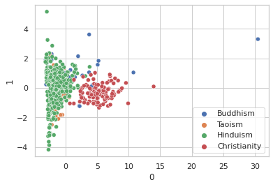

```python
# jak to wyglada w rzeczywistosci
import seaborn as sns
sns.scatterplot(X_compressed.iloc[:, 0], X_compressed.iloc[:, 1], df_labels['4labels'].values )
plt.show()
```

## T-SNE

Plotted for scaled statistical data only (without BoWs).

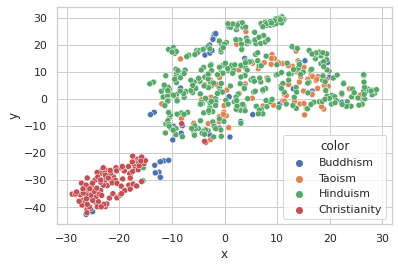

```python
from sklearn.manifold import TSNE

tSNE = TSNE(random_state=12345, verbose=1)
df_csv_tsne_nopca = tSNE.fit_transform(df_scaled_chapters_no_bow)
t = pd.DataFrame({'x': df_csv_tsne_nopca[:, 0],
                    'y': df_csv_tsne_nopca[:, 1],
                    'color': df_labels['4labels']})
sns.scatterplot(data=t, x='x', y='y', hue='color')
plt.show()
```

# Summary

Texts are too similar to divide chapters into 8 books they originate from. However dividing into 4 religions seems like a reasonable goal. As for now, even TSNE did not separate 4 religions, only made some differences between Christian texts and others.

This time we checked PCA and scaling. For the next time we plan to check different scalers (to deal with outliers breaking K-Means) as well as different algorithms such as Agglomeratuce Clustering and others.